```python
#importing libraries
import pandas as pd
import numpy as np
import os
import matplotlib.pyplot as plt
import seaborn as sns
```

```python
#importing data
#create path
path = r'C:\Users\Mathilde\Documents\DATA ANALYSIS CAREERFOUNDRY\May 2024 - Instacart Basket Analysis'
#orders product combined data
ords_prods_merge = pd.read_pickle(os.path.join(path, '02 Data', 'Prepared data', 'ords_prods_merge_derived_w_flags.pkl'))
#new data set - customer data
customers = pd.read_csv(os.path.join(path, '02 Data', 'Original data', 'customers.csv'), index_col = False)
```

# Wrangling the new customers data set

### Exploring the data set

```python
customers.head(5)
```

|  | user_id | First Name | Surnam | Gender | STATE | Age | date_joined | n_dependants | fam_status | income |
| --- | --- | --- | --- | --- | --- | --- | --- | --- | --- | --- |
| 0 | 26711 | Deborah | Esquivel | Female | Missouri | 48 | 1/1/2017 | 3 | married | 165665 |
| 1 | 33890 | Patricia | Hart | Female | New Mexico | 36 | 1/1/2017 | 0 | single | 59285 |
| 2 | 65803 | Kenneth | Farley | Male | Idaho | 35 | 1/1/2017 | 2 | married | 99568 |
| 3 | 125935 | Michelle | Hicks | Female | Iowa | 40 | 1/1/2017 | 0 | single | 42049 |
| 4 | 130797 | Ann | Gilmore | Female | Maryland | 26 | 1/1/2017 | 1 | married | 40374 |

```python
customers.shape
```

```
(206209, 10)
```

```python
customers.describe()
```

|  | user_id | Age | n_dependants | income |
| --- | --- | --- | --- | --- |
| count | 206209.000000 | 206209.000000 | 206209.000000 | 206209.000000 |
| mean | 103105.000000 | 49.501646 | 1.499823 | 94632.852548 |
| std | 59527.555167 | 18.480962 | 1.118433 | 42473.786988 |
| min | 1.000000 | 18.000000 | 0.000000 | 25903.000000 |
| 25% | 51553.000000 | 33.000000 | 0.000000 | 59874.000000 |
| 50% | 103105.000000 | 49.000000 | 1.000000 | 93547.000000 |
| 75% | 154657.000000 | 66.000000 | 3.000000 | 124244.000000 |
| max | 206209.000000 | 81.000000 | 3.000000 | 593901.000000 |

### Observations/Decisions:

To start with, I'll rename a few columns: "Surnam" will become "Last Name" to be coherent with "First Name". "STATE" will become "State".

There don't seem to be any outlier in user_id, Age and n_dependants. Min, Max and mean seem to make sense. My only doubt is about the income column: the max seems very high. Let's check it out.

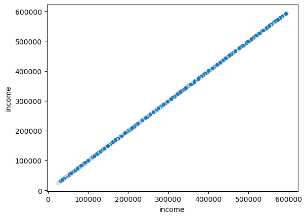

```python
# Create scatter plot to visualize outliers
sns.scatterplot(x = 'income', y = 'income', data = customers)
```

There doesn't seem to b an outlier, the incomes are just higher than I thought they'd be.

### Changing the name of the columns

```python
customers.rename(columns = {'Surnam' : 'Last Name'}, inplace = True)
```

```python
customers.rename(columns = {'STATE' : 'State'}, inplace = True)
```

```python
# Check result
customers.head(5)
```

|  | user_id | First Name | Last Name | Gender | State | Age | date_joined | n_dependants | fam_status | income |
| --- | --- | --- | --- | --- | --- | --- | --- | --- | --- | --- |
| 0 | 26711 | Deborah | Esquivel | Female | Missouri | 48 | 1/1/2017 | 3 | married | 165665 |
| 1 | 33890 | Patricia | Hart | Female | New Mexico | 36 | 1/1/2017 | 0 | single | 59285 |
| 2 | 65803 | Kenneth | Farley | Male | Idaho | 35 | 1/1/2017 | 2 | married | 99568 |
| 3 | 125935 | Michelle | Hicks | Female | Iowa | 40 | 1/1/2017 | 0 | single | 42049 |
| 4 | 130797 | Ann | Gilmore | Female | Maryland | 26 | 1/1/2017 | 1 | married | 40374 |

### Dropping columns?

According to the project brief, the marketing teams would like answers to the questions: "Are there differences in ordering habits based on a customer’s region? Is there a connection between age and family status in terms of ordering habits? What different classifications does the demographic information suggest? Age? Income? Certain types of goods? Family status?"

We definitely need the State, Age, fam_status and income columns. n_dependants also has to do with the family status profiling. However, we do not need the genders, the date they joined, nor the names. Let's drop them.

```python
# Creating a new df without the useless columns - preferred not to overwrite for now
customers2=customers.drop(columns = ['First Name', 'Last Name', 'Gender', 'date_joined'])
```

```python
# Check
customers2.head(5)
```

|  | user_id | State | Age | n_dependants | fam_status | income |
| --- | --- | --- | --- | --- | --- | --- |
| 0 | 26711 | Missouri | 48 | 3 | married | 165665 |
| 1 | 33890 | New Mexico | 36 | 0 | single | 59285 |
| 2 | 65803 | Idaho | 35 | 2 | married | 99568 |
| 3 | 125935 | Iowa | 40 | 0 | single | 42049 |
| 4 | 130797 | Maryland | 26 | 1 | married | 40374 |

### Change data type?

```python
customers2['user_id'].dtype
```

```
dtype('int64')
```

```python
ords_prods_merge['user_id'].dtype
```

```
dtype('int64')
```

I was about to change user_id to string, but I need it to be the same data typ as user_id in the ords_prods_merge data set for later combining. And it would take a lot of computing power to change the data type in the ords_prods_merge data set. So let's keep it this way, having user_id as an int64 instead of string is not a big issue.

# Data quality - consistency check

```python
#Checking for missing values
customers2.isnull().sum()
```

```
user_id         0
State           0
Age             0
n_dependants    0
fam_status      0
income          0
dtype: int64
```

No missing values.

```python
# Checking for duplicates
customers2[customers2.duplicated()]
```

|  | user_id | State | Age | n_dependants | fam_status | income |
| --- | --- | --- | --- | --- | --- | --- |

No duplicates.

```python
# Checking (again) for inconsistencies
customers2.describe()
```

|  | user_id | Age | n_dependants | income |
| --- | --- | --- | --- | --- |
| count | 206209.000000 | 206209.000000 | 206209.000000 | 206209.000000 |
| mean | 103105.000000 | 49.501646 | 1.499823 | 94632.852548 |
| std | 59527.555167 | 18.480962 | 1.118433 | 42473.786988 |
| min | 1.000000 | 18.000000 | 0.000000 | 25903.000000 |
| 25% | 51553.000000 | 33.000000 | 0.000000 | 59874.000000 |
| 50% | 103105.000000 | 49.000000 | 1.000000 | 93547.000000 |
| 75% | 154657.000000 | 66.000000 | 3.000000 | 124244.000000 |
| max | 206209.000000 | 81.000000 | 3.000000 | 593901.000000 |

No extreme value, all the values seem to make sense.

```python
# Checking for mixed-type columns
for col in customers2.columns.tolist():
  weird = (customers2[[col]].applymap(type) != customers2[[col]].iloc[0].apply(type)).any(axis = 1)
  if len (customers2[weird]) > 0:
    print (col)
```

No mixed-type columns.

# Combining data

Getting memory error. I need to reduct the memory used by ords_prods_merge.

```python
ords_prods_merge.head(5)
```

|  | order_id | user_id | order_number | order_dow | order_hour_of_day | days_since_prior_order | product_id | add_to_cart_order | reordered | product_name | ... | prices | price_range_loc | busiest_day | busiest_period_of_day | max_order | loyalty_flag | avg_price | spending_flag | median_dspo | order_frequency_flag |
| --- | --- | --- | --- | --- | --- | --- | --- | --- | --- | --- | --- | --- | --- | --- | --- | --- | --- | --- | --- | --- | --- |
| 0 | 2539329 | 1 | 1 | 2 | 8 | NaN | 196 | 1 | 0 | Soda | ... | 9.0 | Mid-range product | Regularly busy | Average orders | 10 | New customer | 6.367797 | Low spender | 20.5 | Non-frequent customer |
| 1 | 2539329 | 1 | 1 | 2 | 8 | NaN | 14084 | 2 | 0 | Organic Unsweetened Vanilla Almond Milk | ... | 12.5 | Mid-range product | Regularly busy | Average orders | 10 | New customer | 6.367797 | Low spender | 20.5 | Non-frequent customer |
| 2 | 2539329 | 1 | 1 | 2 | 8 | NaN | 12427 | 3 | 0 | Original Beef Jerky | ... | 4.4 | Low-range product | Regularly busy | Average orders | 10 | New customer | 6.367797 | Low spender | 20.5 | Non-frequent customer |
| 3 | 2539329 | 1 | 1 | 2 | 8 | NaN | 26088 | 4 | 0 | Aged White Cheddar Popcorn | ... | 4.7 | Low-range product | Regularly busy | Average orders | 10 | New customer | 6.367797 | Low spender | 20.5 | Non-frequent customer |
| 4 | 2539329 | 1 | 1 | 2 | 8 | NaN | 26405 | 5 | 0 | XL Pick-A-Size Paper Towel Rolls | ... | 1.0 | Low-range product | Regularly busy | Average orders | 10 | New customer | 6.367797 | Low spender | 20.5 | Non-frequent customer |

5 rows × 22 columns

```python
# Change data types to save memory in ords_prods_merge
ords_prods_merge['order_id']=ords_prods_merge['order_id'].astype('int32')
ords_prods_merge['user_id'] = ords_prods_merge['user_id'].astype('int32')
ords_prods_merge['order_number']=ords_prods_merge['order_number'].astype('int8')
ords_prods_merge['order_dow']=ords_prods_merge['order_dow'].astype('int8')
ords_prods_merge['order_hour_of_day']=ords_prods_merge['order_hour_of_day'].astype('int8')
ords_prods_merge['days_since_prior_order']=ords_prods_merge['days_since_prior_order'].astype('float16')
```

```python
# Make sure the type matches between customers2 and ords_prods_merge. Ans save memory there as well
customers2['user_id'] = customers2['user_id'].astype('int32')
customers2['Age'] = customers2['Age'].astype('int8')
customers2['n_dependants'] = customers2['n_dependants'].astype('int8')
customers2['income'] = customers2['income'].astype('int32')
```

Memory issue persists. Switching to plan B - split the big data frame into two smaller pieces.

```python
%%time

ords_prods_merge_key = ords_prods_merge['user_id']

# Creating an empty shell to save the result
df_result = pd.DataFrame(columns=(customers2.columns.append(ords_prods_merge.columns)).unique())
df_result.to_csv(os.path.join(path, '02 Data', 'Prepared Data', "df3.csv"),index_label=False)

# Deleting ords_prods_merge to save memory (the large one)
del(ords_prods_merge)

# The basic idea is that we'll now load the large data set into chunks and then create a function that will
# iteratively merge those chunks to the main data set


# Define a function that will merge the chunks
def preprocess(x):
    ords_prods_merge = pd.merge(customers2,x, left_on = "user_id", right_on = "user_id")
    ords_prods_merge.to_csv(os.path.join(path, '02 Data', 'Prepared Data', "df3.csv"),mode="a",header=False,index=False)


reader = pd.read_csv(os.path.join(path, '02 Data', 'Original Data', 'ords_prods_merge_derived_w_flags.pkl'), chunksize=10000) # chunksize depends on you colsize

[preprocess(r) for r in reader]
```

[output not shown]

```python
# User_id is the common "key" between the 2 data sets
# df_merged_total = ords_prods_merge.merge(customers2, on = 'user_id', indicator = True)
```

[output not shown]

[output cut: 41 more lines]

[output not shown]